# Lab week 2 - Overfitting and its remedies

Data Science and Machine Learning 1 - CEU 2018

Jeno Pal

2018-01-16

```r
library(data.table)
library(ggplot2)
library(GGally) # ggplot extensions, install if it is missing
library(caret)
library(rpart)
theme_set(theme_bw())   # globally set ggplot theme
set.seed(1234)
```

## Data: King County house sales

The dataset was downloaded from [Kaggle](https://www.kaggle.com/harlfoxem/housesalesprediction).

```r
# https://www.kaggle.com/harlfoxem/housesalesprediction/data
data <- fread("../../data/king_county_house_prices/kc_house_data.csv")
str(data)
```

```
Classes ‘data.table’ and 'data.frame':  21613 obs. of  21 variables:
 $ id           : chr  "7129300520" "6414100192" "5631500400" "2487200875" ...
 $ date         : chr  "20141013T000000" "20141209T000000" "20150225T000000" "20141209T000000" ...
 $ price        : num  221900 538000 180000 604000 510000 ...
 $ bedrooms     : int  3 3 2 4 3 4 3 3 3 3 ...
 $ bathrooms    : num  1 2.25 1 3 2 4.5 2.25 1.5 1 2.5 ...
 $ sqft_living  : int  1180 2570 770 1960 1680 5420 1715 1060 1780 1890 ...
 $ sqft_lot     : int  5650 7242 10000 5000 8080 101930 6819 9711 7470 6560 ...
 $ floors       : chr  "1" "2" "1" "1" ...
 $ waterfront   : int  0 0 0 0 0 0 0 0 0 0 ...
 $ view         : int  0 0 0 0 0 0 0 0 0 0 ...
 $ condition    : int  3 3 3 5 3 3 3 3 3 3 ...
 $ grade        : int  7 7 6 7 8 11 7 7 7 7 ...
 $ sqft_above   : int  1180 2170 770 1050 1680 3890 1715 1060 1050 1890 ...
 $ sqft_basement: int  0 400 0 910 0 1530 0 0 730 0 ...
 $ yr_built     : int  1955 1951 1933 1965 1987 2001 1995 1963 1960 2003 ...
 $ yr_renovated : int  0 1991 0 0 0 0 0 0 0 0 ...
 $ zipcode      : chr  "98178" "98125" "98028" "98136" ...
 $ lat          : num  47.5 47.7 47.7 47.5 47.6 ...
 $ long         : num  -122 -122 -122 -122 -122 ...
 $ sqft_living15: int  1340 1690 2720 1360 1800 4760 2238 1650 1780 2390 ...
 $ sqft_lot15   : int  5650 7639 8062 5000 7503 101930 6819 9711 8113 7570 ...
 - attr(*, ".internal.selfref")=<externalptr>
```

```r
# some cleaning and a new variable
data[, `:=`(floors = as.numeric(floors), zipcode = factor(zipcode))]
data[, log_price := log(price)]
# we won't need some variables
data[, c("id", "date", "sqft_living15", "sqft_lot15") := NULL]
```

Look at the outcome variable, the price of houses.

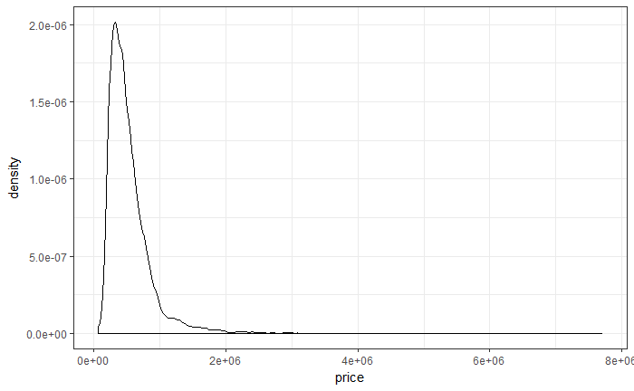

```r
ggplot(data = data, aes(x = price)) + geom_density()
```

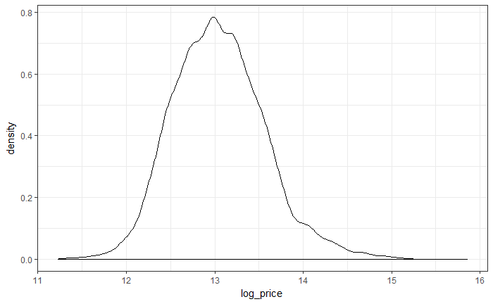

```r
ggplot(data = data, aes(x = log_price)) + geom_density()
```

Let’s see correlations of features and the outcome variable. Based on this, simple benchmark models can quickly be put together.

```
data in column(s) 'zipcode' are not numeric and were ignored
```

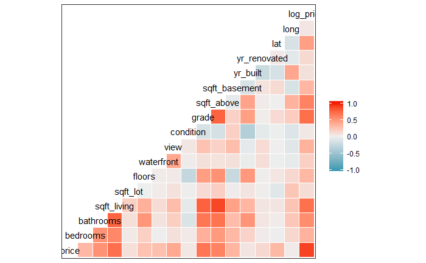

```r
ggcorr(data)
```

[output not shown]

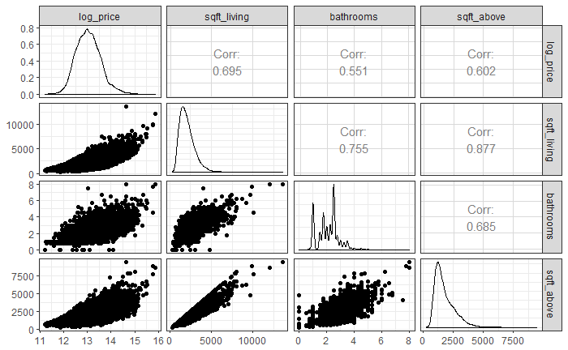

```r
ggpairs(data, columns = c("log_price", "sqft_living", "bathrooms", "sqft_above"))
```

## Overfitting

Let’s use `log_price` as the outcome as less skewed distributions are more amenable for modelling (large values do not distort performance measures that much).

```r
training_ratio <- 0.5
train_indices <- createDataPartition(y = data[["log_price"]],
                                     times = 1,
                                     p = training_ratio,
                                     list = FALSE)
data_train <- data[train_indices, ]
data_test <- data[-train_indices, ]
```

Let’s train a regression tree using the `rpart` package. The parameter `cp` controls how complex the model is: at least `cp` increase in R squared is required for another cut to be made. Hence, the lower `cp` is, the more cuts there are in the tree, the more complex the model is.

```r
RMSE <- function(x, true_x) sqrt(mean((x - true_x)^2))
regularization_parameters <- c(0.01, 0.001, 0.0001, 0.00001, 0.000001)
n_parameters <- length(regularization_parameters)
train_error <- rep(0, length(regularization_parameters))
test_error <- rep(0, length(regularization_parameters))
for (ix in 1:n_parameters) {
  param <- regularization_parameters[ix]
  model <- rpart(
            formula = log_price ~ . - price,
            data = data_train,
            control = rpart.control(xval = 0,  # no cross validations
                                    cp = param),
            method = "anova"
        )
  train_error[ix] <- RMSE(predict(model, data_train),
                          data_train[["log_price"]])
  test_error[ix] <- RMSE(predict(model, data_test),
                         data_test[["log_price"]])
}
errors <- data.table("parameter" = regularization_parameters,
                     "train_error" = train_error,
                     "test_error" = test_error)
```

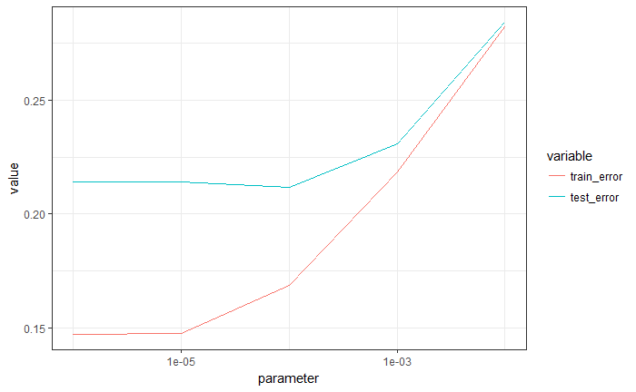

```r
errors_long <- melt(errors, id.vars = "parameter")
ggplot(data = errors_long) +
  geom_line(aes(x = parameter, y = value, color = variable)) +
  scale_x_log10()
```

It is visible that while error on the training set decreases with more complex models, this is not true on the independent test set.

## Cross-validation

```r
fit_control <- trainControl(method = "cv", number = 10)
tune_grid <- data.frame("cp" = c(0.01, 0.001, 0.0001, 0.00001, 0.000001))
```

```r
# select best model parameter: hyperparameter tuning
set.seed(857)
rpart_fit <- train(log_price ~ . -price,
                   data = data_train,
                   method = "rpart",
                   trControl = fit_control,
                   tuneGrid = tune_grid)
rpart_fit
```

```
CART

10807 samples
   17 predictor

No pre-processing
Resampling: Cross-Validated (10 fold)
Summary of sample sizes: 9727, 9726, 9727, 9725, 9726, 9725, ...
Resampling results across tuning parameters:

  cp     RMSE       Rsquared   MAE
  1e-06  0.2233343  0.8217208  0.1609661
  1e-05  0.2233056  0.8217599  0.1608262
  1e-04  0.2221368  0.8226600  0.1604132
  1e-03  0.2448488  0.7834894  0.1806968
  1e-02  0.3012289  0.6719286  0.2273597

RMSE was used to select the optimal model using the smallest value.
The final value used for the model was cp = 1e-04.
```

```r
# finalModel: refit using _all_ of the training data using the best parameter
# combination
```

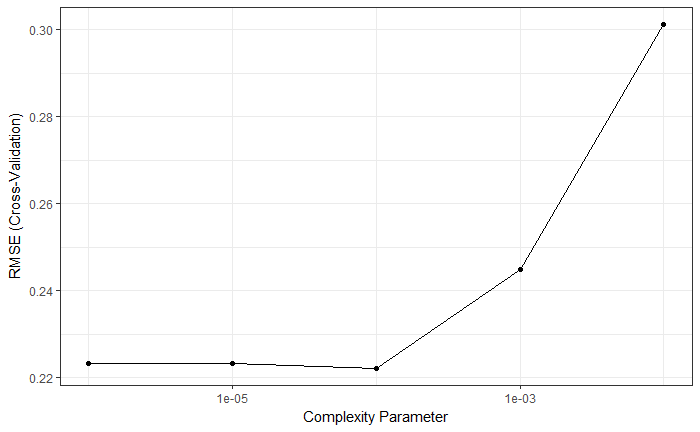

```r
# note: there is a ggplot method for caret fit objects!
ggplot(rpart_fit) + scale_x_log10()
```

When trained this way, cross-validation is used for **hyperparameter tuning**: selecting the best value for a model parameter based on data.

### Choose simple model that is good enough

One can instruct `caret` to choose a model that is not the best but one that is close to it and is as simple as possible. There is a built-in option for choosing the simplest model within 1 standard deviation from the best choice.

Also, CV can be repeated so that the standard deviation estimation is more precise.

```r
fit_control <- trainControl(method = "repeatedcv",
                            number = 10,
                            repeats = 5, # repeat CV 5 times
                            selectionFunction = "oneSE")
tune_grid <- data.frame("cp" = c(0.01, 0.005,
                                 0.001, 0.0005,
                                 0.0001, 0.00005,
                                 0.00001, 0.000005))
set.seed(857)
rpart_fit <- train(log_price ~ . -price,
                   data = data_train,
                   method = "rpart",
                   trControl = fit_control,
                   tuneGrid = tune_grid)  # tuneLength: caret chooses 10 parameters
rpart_fit
```

```
CART

10807 samples
   17 predictor

No pre-processing
Resampling: Cross-Validated (10 fold, repeated 5 times)
Summary of sample sizes: 9727, 9726, 9727, 9725, 9726, 9725, ...
Resampling results across tuning parameters:

  cp     RMSE       Rsquared   MAE
  5e-06  0.2216890  0.8242569  0.1606054
  1e-05  0.2217139  0.8242156  0.1606030
  5e-05  0.2204541  0.8258097  0.1592116
  1e-04  0.2203821  0.8254788  0.1596774
  5e-04  0.2328836  0.8043422  0.1711091
  1e-03  0.2435814  0.7858610  0.1800547
  5e-03  0.2764797  0.7240414  0.2069266
  1e-02  0.3007092  0.6733959  0.2267592

RMSE was used to select the optimal model using  the one SE rule.
The final value used for the model was cp = 1e-04.
```

choose simple rule within small margin of best (1 standard deviation rule? see ?best oneSE. selectionFunction argument)

## Model selection

### Tune other types of models

#### A simple benchmark

It is always a good idea to choose a simple benchmark and see how more complicated models perform compared to this.

```r
# same seed as above - results in exactly the same cuts for cross-validation
set.seed(857)
linear_fit <- train(log_price ~ sqft_living + bathrooms + sqft_above + yr_built,
                    method = "lm",
                    data = data_train,
                    trControl = fit_control)
```

Train a lasso model as well, then choose between this and the previously seen regression tree.

```r
# lasso model
glm_tune_grid <- expand.grid("alpha" = 1,
                             "lambda" = c(0.1, 0.01, 0.001, 0.0001))
set.seed(857)
lasso_fit <- train(log_price ~ . -price,
                   data = data_train,
                   method = "glmnet",
                   preProcess = c("center", "scale"),
                   tuneGrid = glm_tune_grid,
                   trControl = fit_control)
```

Choice can be based on: - cross-validation + assuming exactly the same cuts have been made - held-out validation set

### Model selection via cross validation

```r
resamps <- resamples(list("regression tree" = rpart_fit,
                          "lasso" = lasso_fit,
                          "linear" = linear_fit))
summary(resamps)
```

```
Call:
summary.resamples(object = resamps)

Models: regression tree, lasso, linear
Number of resamples: 50

MAE
                     Min.   1st Qu.    Median      Mean   3rd Qu.      Max. NA's
regression tree 0.1435733 0.1566941 0.1600854 0.1596774 0.1630508 0.1709192    0
lasso           0.1280483 0.1362698 0.1387397 0.1389667 0.1419623 0.1469689    0
linear          0.2785258 0.2902580 0.2940011 0.2936397 0.2982608 0.3040517    0

RMSE
                     Min.   1st Qu.    Median      Mean   3rd Qu.      Max. NA's
regression tree 0.1928527 0.2153938 0.2203937 0.2203821 0.2254413 0.2424081    0
lasso           0.1694208 0.1833152 0.1880507 0.1882690 0.1929170 0.2016525    0
linear          0.3458135 0.3581814 0.3650663 0.3641372 0.3703182 0.3772687    0

Rsquared
                     Min.   1st Qu.    Median      Mean   3rd Qu.      Max. NA's
regression tree 0.7982815 0.8154151 0.8256717 0.8254788 0.8337524 0.8567498    0
lasso           0.8474644 0.8661574 0.8715292 0.8719517 0.8773159 0.8912597    0
linear          0.4734024 0.5080112 0.5205148 0.5209919 0.5331805 0.5637716    0
```

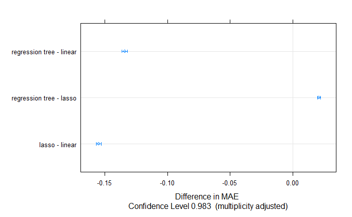

```r
diff_resamples <- diff(resamps)
dotplot(diff_resamples)
```

Final model performance evaluation on independet test set not used for hyperparameter tuning or model selection:

```r
test_prediction <- predict.train(lasso_fit, newdata = data_test)
RMSE(test_prediction, data_test[["log_price"]])
```

```
[1] 0.1904232
```